# Portfolio 2.2, Methods 3, 2021, autumn semester

Laura W. Paaby, studygroup 9

13/10 - 2021

# Exercises and objectives

The objectives of the exercises of this assignment are based on: https://doi.org/10.1016/j.concog.2019.03.007

4. Download and organise the data from experiment 1
5. Use log-likelihood ratio tests to evaluate logistic regression models
6. Test linear hypotheses
7. Estimate psychometric functions for the Perceptual Awareness Scale and evaluate them

REMEMBER: In your report, make sure to include code that can reproduce the answers requested in the exercises below (**MAKE A KNITTED VERSION**)  
REMEMBER: This is part 2 of Assignment 2 and will be part of your final portfolio

# EXERCISE 4 - Download and organise the data from experiment 1

Go to https://osf.io/ecxsj/files/ and download the files associated with Experiment 1 (there should be 29).  
The data is associated with Experiment 1 of the article at the following DOI https://doi.org/10.1016/j.concog.2019.03.007

```r
#loading libraries:
pacman::p_load(tidyverse, readbulk, patchwork, lmerTest, ggpubr, dfoptim, multcomp, dplyr)
```

1. Put the data from all subjects into a single data frame - note that some of the subjects do not have the *seed* variable. For these subjects, add this variable and make in *NA* for all observations. (The *seed* variable will not be part of the analysis and is not an experimental variable)

*since we are using read_bulk the missing values are already noted as NA:*

```r
sum(is.na(data$seed))
```

```
## [1] 2646
```

```
i. Factorise the variables that need factorising
```

```r
#checking out the data:
ls.str(data)
```

```
## cue :  num [1:25602] 0 0 0 0 0 0 0 0 0 0 ...
## even.digit :  num [1:25602] 8 4 2 8 6 6 6 4 4 8 ...
## File :  chr [1:25602] "001.csv" "001.csv" "001.csv" "001.csv" "001.csv" "001.csv" ...
## jitter.x :  num [1:25602] -0.431 -0.292 0.308 0.238 -0.427 ...
## jitter.y :  num [1:25602] -0.335 -0.182 0.406 0.175 -0.221 ...
## obj.resp :  chr [1:25602] "e" "o" "e" "o" "e" "o" "o" "e" "e" "o" "e" "o" "e" "o" "e" ...
## odd.digit :  num [1:25602] 9 5 5 9 3 9 3 5 7 9 ...
## pas :  num [1:25602] 4 4 3 2 3 2 1 1 1 4 ...
## rt.obj :  num [1:25602] 1.418 0.86 0.746 1.676 0.847 ...
## rt.subj :  num [1:25602] 4.93 8.67 8.41 2.13 1.82 ...
## seed :  num [1:25602] 93764 93764 93764 93764 93764 ...
## subject :  chr [1:25602] "001" "001" "001" "001" "001" "001" "001" "001" "001" "001" ...
## target.contrast :  num [1:25602] 0.1 0.1 0.1 0.1 0.1 0.1 0.1 0.1 0.1 0.1 ...
## target.frames :  num [1:25602] 9 8 7 6 5 4 3 2 1 9 ...
## target.type :  chr [1:25602] "even" "odd" "even" "odd" "even" "odd" "even" "odd" "even" ...
## task :  chr [1:25602] "quadruplet" "quadruplet" "quadruplet" "quadruplet" ...
## trial :  num [1:25602] 0 1 2 3 4 5 6 7 8 9 ...
## trial.type :  chr [1:25602] "practice" "practice" "practice" "practice" "practice" ...
```

```r
data$trial.type <- as.factor(data$trial.type)
data$pas <- as.factor(data$pas)
data$trial <- as.factor(data$trial)
data$cue <- as.factor(data$cue)
data$task <- as.factor(data$task)
data$target.type <- as.factor(data$target.type)
data$obj.resp <- as.factor(data$obj.resp)
data$subject <- as.factor(data$subject)
```

$~$ *The factorisation of variables have been made on the basis of Assignment 2 Part 1, in which arguments were presented for the factorisation as well.*

```
ii. Remove the practice trials from the dataset (see the _trial.type_ variable)
```

```r
data_exp <- data %>%
  filter(trial.type == "experiment")
```

```
iii. Create a _correct_ variable
```

```r
data_exp$correct <- ifelse((data_exp$obj.resp == "o" & data_exp$target.type =="odd") | (data_exp$obj.resp == "e" & data_exp$target.type =="even"), 1,0)
```

```
iv. Describe how the _target.contrast_ and _target.frames_ variables differ compared to the data from part 1 of this assignment
```

*target contrast is now only one value: 0.1. Which is the contrast on the screen between the target and the background. This is now a constant, opposite the previous experiment.*

```r
summary(data_exp$target.contrast)
```

```
##    Min. 1st Qu.  Median    Mean 3rd Qu.    Max.
##     0.1     0.1     0.1     0.1     0.1     0.1
```

$~$ *target frame are now a ordinal, non-continuous variable, as seen in the summary and the histogram, which also indicates that there is the same amount of counts in each target frame. This is opposite the old dataset, where the frame was a constant. It is the amound of frames in which the target is shown.*

```r
summary(data_exp$target.frames)
```

```
##    Min. 1st Qu.  Median    Mean 3rd Qu.    Max.
##     1.0     2.0     3.5     3.5     5.0     6.0
```

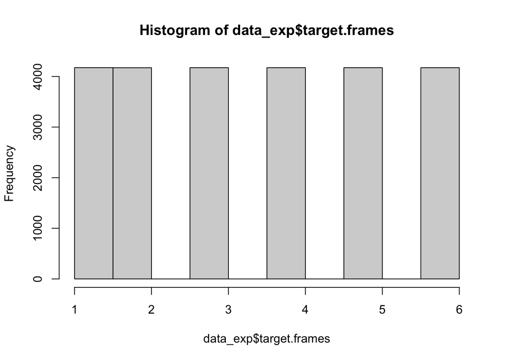

```r
hist(data_exp$target.frames)
```

# EXERCISE 5 - Use log-likelihood ratio tests to evaluate logistic regression models

1. Do logistic regression - *correct* as the dependent variable and *target.frames* as the independent variable. (Make sure that you understand what *target.frames* encode). Create two models - a pooled model (**m5.1.pook**) and a partial-pooling model. The partial-pooling (**m5.1.partpool**) model should include a subject-specific intercept.

```r
m5.1.pool <- glm(correct ~ target.frames, family = binomial, data = data_exp)
m5.1.partpool <- glmer(correct ~ target.frames + (1 | subject), family = binomial, data = data_exp)
```

```
i. the likelihood-function for logistic regression is:
```

$L(p)={\displaystyle\prod_{i=1}^Np^{y_i}(1-p)^{(1-y_i)}}$ (Remember the probability mass function for the Bernoulli Distribution). Create a function that calculates the likelihood.

```r
# Likelihood-Function for logistic regression based on the prob-mass-func.
like_funct <- function(model, df, y){
  prob <- fitted(model)

  return(prod(prob^y*(1-prob)^(1-y)))
}
```

```
ii. the log-likelihood-function for logistic regression is: $l(p) = {\displaystyle\sum_{i=1}^N}[y_i\ln{p}+(1-y_i)\ln{(1-p)}$. Create a function that calculates the log-likelihood
```

```r
# Log-Likelihood-Function for logistic regression
log_like_funct <- function(model, df, y){
  prob <- fitted(model)

  sum((y*(log(prob)) + (1-y)*log(1-prob)))

}
```

```
iii. apply both functions to the pooling model you just created. Make sure that the log-likelihood matches what is returned from the _logLik_ function for the pooled model.
```

```r
#using the functions on the pooled model:
pool_prob_like <- like_funct(m5.1.pool, data_exp, data_exp$correct)
pool_prob_likelog <- log_like_funct(m5.1.pool, data_exp, data_exp$correct)

#the outcome:
pool_prob_like
```

```
## [1] 0
```

```r
pool_prob_likelog
```

```
## [1] -10865.25
```

Does the likelihood-function return a value that is surprising? *It seems a bit odd that the likelihood estimate is a 0, however considering the huge size of the data and how small the values are, it isn’t that suprising after all that it ends on a 0 (also considering the limited precision of the likelihood function).*

```r
log_like_r <- logLik(m5.1.pool)

compare_prob <- tibble("Estimated Likelihood Log" =c(pool_prob_likelog), "logLik" = c(log_like_r))
compare_prob
```

| Estimated Likelihood Log | logLik |
| --- | --- |
| -10865.25 | -10865.25 |

Why is the log-likelihood preferable when working with computers with limited precision? *When calculating the likelihood numbers are multiplied together - are these small the numbers will be to small in the end for the computer to comprehend it. Additionally a 0 in this line of numbers will result in it all becoming 0, and not interpretable. Therefore the log-likelihood is preferred, since we then avoid super small numbers and 0’s. It simply does not require as much computational precision.*

```
iv. now show that the log-likelihood is a little off when applied to the partial pooling model - (the likelihood function is different for the multilevel function - see section 2.1 of https://www.researchgate.net/profile/Douglas-Bates/publication/2753537_Computational_Methods_for_Multilevel_Modelling/links/00b4953b4108d73427000000/Computational-Methods-for-Multilevel-Modelling.pdf if you are interested)
```

```r
log_like_r1 <- logLik(m5.1.partpool)
part_pool1 <- log_like_funct(m5.1.partpool, data_exp, data_exp$correct)

compare_prob1 <- tibble("Estimated Likelihood Log Part Pool" =c(part_pool1), "logLik Part Pool" = c(log_like_r1))
compare_prob1
```

| Estimated Likelihood Log Part Pool | logLik Part Pool |
| --- | --- |
| -10565.53 | -10622.03 |

$~$ *As showed, there is a slight difference between the two log-likelihoods*

2. Use log-likelihood ratio tests to argue for the addition of predictor variables, start from the null model, `glm(correct ~ 1, 'binomial', data)` (*m2.1*), then **add** subject-level intercepts (*m2.2*), then add a group-level effect of *target.frames* (*m2.3*) and finally add subject-level slopes for *target.frames*.(*m2.4*)

Also assess whether or not a correlation between the subject-level slopes and the subject-level intercepts should be included. (*m2.5*)

```r
#the null model
m2.1 <- glm(correct ~ 1, family = binomial, data = data_exp)
llrt2.1 <- log_like_funct(m2.1, data_exp, data_exp$correct)

#added sub level intercepts
m2.2 <- glmer(correct ~ 1 + (1|subject), family = binomial, data = data_exp)
llrt2.2 <- log_like_funct(m2.2, data_exp, data_exp$correct)

#added group-level effect of target frames
m2.3 <- glmer(correct ~ target.frames + (1|subject), family = binomial, data = data_exp)
llrt2.3 <- log_like_funct(m2.3, data_exp, data_exp$correct)

#without correlation between slope and intercept (2 times |) and with subject-level effect of target.frames
m2.4 <- glmer(correct ~ target.frames + (1 + target.frames || subject), family = binomial, data = data_exp)
llrt2.4 <- log_like_funct(m2.4, data_exp, data_exp$correct)

#equal to the previous, but with correlation between slope and intercept (only one |)
m2.5 <- glmer(correct ~ target.frames + (1 + target.frames | subject), family = binomial, data = data_exp)
llrt2.5 <- log_like_funct(m2.5, data_exp, data_exp$correct)

#anova comparison
anov <- anova(m2.2, m2.3, m2.4, m2.5, m2.1)
anov
```

|  | npar | AIC | BIC | logLik | deviance | Chisq | Df | Pr(>Chisq) |
| --- | --- | --- | --- | --- | --- | --- | --- | --- |
| m2.1 | 1 | 26685.08 | 26693.21 | -13341.54 | 26683.08 | NA | NA | NA |
| m2.2 | 2 | 26319.10 | 26335.35 | -13157.55 | 26315.10 | 367.97976 | 1 | 5.153061e-82 |
| m2.3 | 3 | 21250.06 | 21274.45 | -10622.03 | 21244.06 | 5071.03518 | 1 | 0.000000e+00 |
| m2.4 | 4 | 20928.58 | 20961.09 | -10460.29 | 20920.58 | 323.48672 | 1 | 2.520170e-72 |
| m2.5 | 5 | 20907.65 | 20948.29 | -10448.83 | 20897.65 | 22.92598 | 1 | 1.683609e-06 |

```r
#comparison by log likelihood and anova summary
compare_prob2 <- tibble("Model" = c("Null Model m2.1", "Sub Intercept Model m2.2", "Target Frames Effect m2.3", "No Correlation between Random Effects m2.4", "Correlation Between Random Effects m2.5"), "Log Likelihood RT" =c(llrt2.1, llrt2.2, llrt2.3, llrt2.4, llrt2.5))
compare_prob2
```

| Model | Log Likelihood RT |
| --- | --- |
| Null Model m2.1 | -13341.54 |
| Sub Intercept Model m2.2 | -13105.03 |
| Target Frames Effect m2.3 | -10565.53 |
| No Correlation between Random Effects m2.4 | -10378.96 |
| Correlation Between Random Effects m2.5 | -10375.14 |

```
i. write a short methods section and a results section where you indicate which model you chose and the statistics relevant for that choice.
```

*When comparing models by their log-likelihood ratio, one should look for the higher value, since one wants it to be maximized. In this case I would therefore suggest model 2.5: glmer(correct ~ target.frames + (1 + target frames|subject), family = binomial) which has the target frames as the fixed effects, subject as the random intercept and a correlation between the subject level slopes and intercepts: which has a log likelihood ratio value of -10375.14.*

*Additionally … it can be seen how the results of an anova comparison indicates the same finding - the model perform best in the anova as well, leading me to suggest that a correlation should be included in our model*

```r
summary(m2.4)
```

```
## Generalized linear mixed model fit by maximum likelihood (Laplace
##   Approximation) [glmerMod]
##  Family: binomial  ( logit )
## Formula: correct ~ target.frames + (1 + target.frames || subject)
##    Data: data_exp
##
##      AIC      BIC   logLik deviance df.resid
##  20928.6  20961.1 -10460.3  20920.6    25040
##
## Scaled residuals:
##      Min       1Q   Median       3Q      Max
## -14.1977   0.0898   0.2470   0.4894   1.3292
##
## Random effects:
##  Groups    Name          Variance Std.Dev.
##  subject   (Intercept)   0.0360   0.1897
##  subject.1 target.frames 0.0366   0.1913
## Number of obs: 25044, groups:  subject, 29
##
## Fixed effects:
##               Estimate Std. Error z value Pr(>|z|)
## (Intercept)   -1.06926    0.05083  -21.04   <2e-16 ***
## target.frames  0.82207    0.03817   21.54   <2e-16 ***
## ---
## Signif. codes:  0 '***' 0.001 '**' 0.01 '*' 0.05 '.' 0.1 ' ' 1
##
## Correlation of Fixed Effects:
##             (Intr)
## target.frms -0.230
```

Include a plot of the estimated group-level function with `xlim=c(0, 8)` that includes the estimated subject-specific functions.

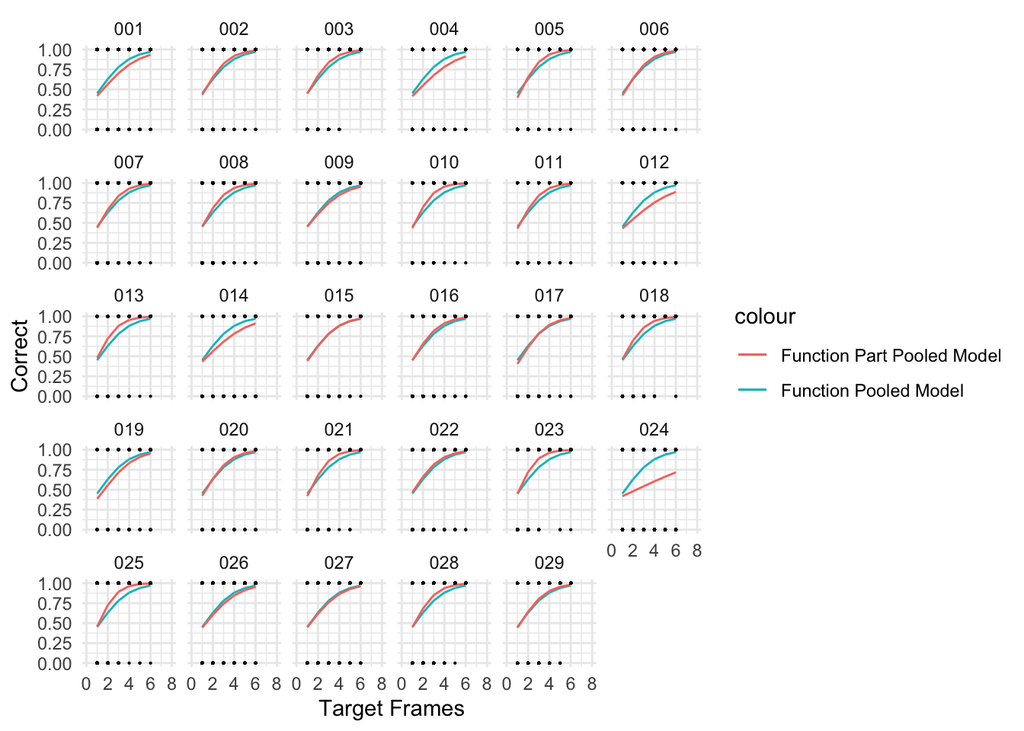

```r
#fitted values from the pool model to compare
pool.fit <- fitted(m5.1.pool)

#fitted values over the chosen model
m5.fit <- fitted(m2.5)


plot2 <- ggplot(data_exp, aes(target.frames, as.numeric(as.character(correct)))) +
    geom_line(aes(x = target.frames, y = pool.fit, color = "Function Pooled Model"))+
    geom_line(aes(x = target.frames, y = m5.fit, color = "Function Part Pooled Model"))+
    geom_point(aes(y = as.numeric(as.character(correct), color = "Response")), size = 0.07) +
   facet_wrap(~subject)+
  xlim(min = 0, max = 8)+
    theme_minimal()+
    xlab("Target Frames")+
    ylab('Correct')


plot2
```

$~$ *The dots: Are the responses given by each participant (0 being wrong, 1 correct)*

*By eyeballing the plot it appears as if the function for subject 24 looks rather different that the group-specific function. One could additionally compare the subject specific function with the group specific, and find that in many cases there is a bit of a difference.*

```
ii. also include in the results section whether the fit didn't look good for any of the subjects. If so, identify those subjects in the report, and judge (no statistical test) whether their performance (accuracy) differed from that of the other subjects. Was their performance better than chance? (Use a statistical test this time) (50 %)
```

```r
data_24 <- data_exp %>%
  filter(subject == "024")

t.test(x = data_24$correct, mu = 0.5)
```

```
##
##  One Sample t-test
##
## data:  data_24$correct
## t = 4.026, df = 873, p-value = 6.167e-05
## alternative hypothesis: true mean is not equal to 0.5
## 95 percent confidence interval:
##  0.5345964 0.6004150
## sample estimates:
## mean of x
## 0.5675057
```

$~$ *Inspecting the one-sampled t-test, we see whether the performance of subject 24 was better than if the outcomes were due to pure chance (hence the 0.5, which is the value it should be compared by) - this indicates there is a significant difference (p < .001) between the subject 24 performance and a performance achieved by chance.*

3. Now add *pas* to the group-level effects - if a log-likelihood ratio test justifies this, also add the interaction between *pas* and *target.frames* and check whether a log-likelihood ratio test justifies this

```r
#pas as group level effect
m3.1 <- glmer(correct ~ target.frames + pas + (1 + target.frames | subject), family = binomial, data = data_exp)

#pas as interaction with target.frames
m3.2 <- glmer(correct ~ target.frames * pas + (1 + target.frames | subject), family = binomial, data = data_exp)
```

```
i. if your model doesn't converge, try a different optimizer
```

*it appears to be working :D*

```r
#does log-like justify????
log_compare <- tibble("Model" = c("m2.5", "m.3.1", "m3.2"), "Type" = c("Correlation Model without Pas", "With Pas as Group Level Effect", "With Pas As Interaction"), "Log-Like Value" = c(log_like_funct(m2.5, data_exp, data_exp$correct), log_like_funct(m3.1, data_exp, data_exp$correct), log_like_funct(m3.2, data_exp, data_exp$correct)))

log_compare
```

| Model | Type | Log-Like Value |
| --- | --- | --- |
| m2.5 | Correlation Model without Pas | -10375.136 |
| m.3.1 | With Pas as Group Level Effect | -9860.225 |
| m3.2 | With Pas As Interaction | -9684.128 |

$~$ *Seeing how the Log-Likelihood Value increases by adding PAS as interaction, it can be justified to add this to our model. Our final model is now m3.2: glmer(correct ~ target.frames* * *pas + (1 + target.frames | subject), family = binomial).*

```
ii. plot the estimated group-level functions over `xlim=c(0, 8)` for each of the four PAS-ratings - add this plot to your report (see: 5.2.i) and add a description of your chosen model. Describe how _pas_ affects accuracy together with target duration if at all.
```

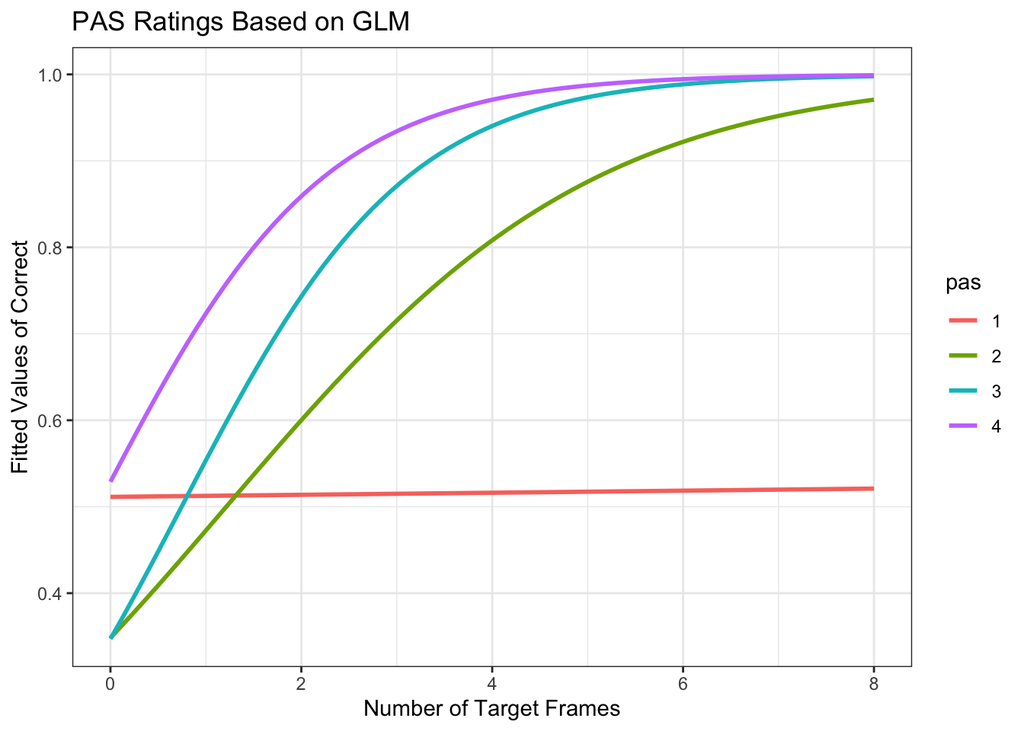

```r
data_exp$fit_mod <- fitted.values(m3.2)

plot_5.3 <- data_exp %>%
  ggplot(aes(target.frames, fit_mod)) +
  geom_smooth(aes(colour = pas), method = "glm", method.args = list(family = "binomial"), se = FALSE, fullrange = TRUE) +
  xlim(0,8) +
  ylab("Fitted Values of Correct") +
  xlab("Number of Target Frames") +
  ggtitle("PAS Ratings Based on GLM")+
  theme_bw()

plot_5.3
```

```r
#summary of the chosen model:
summary(m3.2)
```

```
## Generalized linear mixed model fit by maximum likelihood (Laplace
##   Approximation) [glmerMod]
##  Family: binomial  ( logit )
## Formula: correct ~ target.frames * pas + (1 + target.frames | subject)
##    Data: data_exp
##
##      AIC      BIC   logLik deviance df.resid
##  19506.1  19595.5  -9742.0  19484.1    25033
##
## Scaled residuals:
##      Min       1Q   Median       3Q      Max
## -19.0116   0.0537   0.1607   0.4849   1.4465
##
## Random effects:
##  Groups  Name          Variance Std.Dev. Corr
##  subject (Intercept)   0.03697  0.1923
##          target.frames 0.02057  0.1434   -0.76
## Number of obs: 25044, groups:  subject, 29
##
## Fixed effects:
##                    Estimate Std. Error z value Pr(>|z|)
## (Intercept)        -0.12164    0.06419  -1.895 0.058081 .
## target.frames       0.11480    0.03710   3.095 0.001971 **
## pas2               -0.57138    0.08948  -6.386 1.71e-10 ***
## pas3               -0.53844    0.13980  -3.852 0.000117 ***
## pas4                0.20147    0.25132   0.802 0.422758
## target.frames:pas2  0.44718    0.03477  12.863  < 2e-16 ***
## target.frames:pas3  0.74867    0.04602  16.270  < 2e-16 ***
## target.frames:pas4  0.75930    0.06867  11.057  < 2e-16 ***
## ---
## Signif. codes:  0 '***' 0.001 '**' 0.01 '*' 0.05 '.' 0.1 ' ' 1
##
## Correlation of Fixed Effects:
##             (Intr) trgt.f pas2   pas3   pas4   trg.:2 trg.:3
## target.frms -0.811
## pas2        -0.462  0.306
## pas3        -0.308  0.208  0.249
## pas4        -0.175  0.124  0.123  0.091
## trgt.frms:2  0.482 -0.429 -0.874 -0.246 -0.125
## trgt.frms:3  0.393 -0.359 -0.279 -0.891 -0.111  0.371
## trgt.frms:4  0.276 -0.260 -0.164 -0.121 -0.919  0.226  0.200
```

*The log-likelihoods from this can now be used to find the estimated behaviour when target.frame = 0*

```r
inv.logit <- function(x) exp(x) / (1 + exp(x))

#intercept - so when targetframe equals 0
inv.logit(-0.12164)
```

```
## [1] 0.4696274
```

```r
#pas 2. here i can see that the probability of answering correct when going from pas 1 to pas 2 is increased with 36%
inv.logit(-0.57138)
```

```
## [1] 0.3609185
```

```r
#pas 3: Here i can see that the probability of answering correct when going from pas 2 to pas 3 is increased with 36%
inv.logit(-0.53844)
```

```
## [1] 0.3685506
```

```r
#pas 4:  here i can see that the probability of answering correct when going from pas 1 to pas 2 is increased with 55%
inv.logit(0.20147)
```

```
## [1] 0.5501978
```

# EXERCISE 6 - Test linear hypotheses

In this section we are going to test different hypotheses. We assume that we have already proved that more objective evidence (longer duration of stimuli) is sufficient to increase accuracy in and of itself and that more subjective evidence (higher PAS ratings) is also sufficient to increase accuracy in and of itself.

We want to test a hypothesis for each of the three neighboring differences in PAS, i.e. the difference between 2 and 1, the difference between 3 and 2 and the difference between 4 and 3. More specifically, we want to test the hypothesis that accuracy increases faster with objective evidence if subjective evidence is higher at the same time, i.e. we want to test for an interaction.

1. Fit a model based on the following formula: `correct ~ pas * target.frames + (target.frames | subject))`
   1. First, use `summary` (yes, you are allowed to!) to argue that accuracy increases faster with objective evidence for PAS 2 than for PAS 1.

```r
#making the model
m6.1 <- glmer(correct ~ pas * target.frames + (1+target.frames | subject), family = binomial(link = "logit"), data = data_exp)

summary(m6.1)
```

```
## Generalized linear mixed model fit by maximum likelihood (Laplace
##   Approximation) [glmerMod]
##  Family: binomial  ( logit )
## Formula: correct ~ pas * target.frames + (1 + target.frames | subject)
##    Data: data_exp
##
##      AIC      BIC   logLik deviance df.resid
##  19506.1  19595.5  -9742.0  19484.1    25033
##
## Scaled residuals:
##      Min       1Q   Median       3Q      Max
## -19.0110   0.0537   0.1606   0.4849   1.4465
##
## Random effects:
##  Groups  Name          Variance Std.Dev. Corr
##  subject (Intercept)   0.03698  0.1923
##          target.frames 0.02057  0.1434   -0.76
## Number of obs: 25044, groups:  subject, 29
##
## Fixed effects:
##                    Estimate Std. Error z value Pr(>|z|)
## (Intercept)        -0.12163    0.06416  -1.896 0.058008 .
## pas2               -0.57140    0.08943  -6.389 1.67e-10 ***
## pas3               -0.53848    0.13956  -3.859 0.000114 ***
## pas4                0.20156    0.25059   0.804 0.421216
## target.frames       0.11480    0.03709   3.095 0.001966 **
## pas2:target.frames  0.44719    0.03475  12.869  < 2e-16 ***
## pas3:target.frames  0.74869    0.04595  16.293  < 2e-16 ***
## pas4:target.frames  0.75928    0.06850  11.084  < 2e-16 ***
## ---
## Signif. codes:  0 '***' 0.001 '**' 0.01 '*' 0.05 '.' 0.1 ' ' 1
##
## Correlation of Fixed Effects:
##             (Intr) pas2   pas3   pas4   trgt.f ps2:t. ps3:t.
## pas2        -0.462
## pas3        -0.308  0.248
## pas4        -0.174  0.121  0.092
## target.frms -0.811  0.306  0.208  0.124
## ps2:trgt.fr  0.482 -0.874 -0.245 -0.124 -0.428
## ps3:trgt.fr  0.393 -0.279 -0.891 -0.112 -0.359  0.371
## ps4:trgt.fr  0.276 -0.163 -0.121 -0.918 -0.260  0.225  0.200
```

```r
######from logit to prob
#for pas 1:
est_1<- (coef(summary(m6.1))[5])
est.inv <- inv.logit(est_1)
est.inv
```

```
## [1] 0.5286684
```

```r
# for pas 2:
est_2<- (coef(summary(m6.1))[5+6])
est_2_inv <- inv.logit(est_2)
est_2_inv
```

```
## [1] 0.5348322
```

2. `summary` won’t allow you to test whether accuracy increases faster with objective evidence for PAS 3 than for PAS 2 (unless you use `relevel`, which you are not allowed to in this exercise). Instead, we’ll be using the function `glht` from the `multcomp` package
   1. To redo the test in 6.1.i, you can create a *contrast* vector. This vector will have the length of the number of estimated group-level effects and any specific contrast you can think of can be specified using this. For redoing the test from 6.1.i, the code snippet below will do:

```r
summary(m6.1)
```

```
## Generalized linear mixed model fit by maximum likelihood (Laplace
##   Approximation) [glmerMod]
##  Family: binomial  ( logit )
## Formula: correct ~ pas * target.frames + (1 + target.frames | subject)
##    Data: data_exp
##
##      AIC      BIC   logLik deviance df.resid
##  19506.1  19595.5  -9742.0  19484.1    25033
##
## Scaled residuals:
##      Min       1Q   Median       3Q      Max
## -19.0110   0.0537   0.1606   0.4849   1.4465
##
## Random effects:
##  Groups  Name          Variance Std.Dev. Corr
##  subject (Intercept)   0.03698  0.1923
##          target.frames 0.02057  0.1434   -0.76
## Number of obs: 25044, groups:  subject, 29
##
## Fixed effects:
##                    Estimate Std. Error z value Pr(>|z|)
## (Intercept)        -0.12163    0.06416  -1.896 0.058008 .
## pas2               -0.57140    0.08943  -6.389 1.67e-10 ***
## pas3               -0.53848    0.13956  -3.859 0.000114 ***
## pas4                0.20156    0.25059   0.804 0.421216
## target.frames       0.11480    0.03709   3.095 0.001966 **
## pas2:target.frames  0.44719    0.03475  12.869  < 2e-16 ***
## pas3:target.frames  0.74869    0.04595  16.293  < 2e-16 ***
## pas4:target.frames  0.75928    0.06850  11.084  < 2e-16 ***
## ---
## Signif. codes:  0 '***' 0.001 '**' 0.01 '*' 0.05 '.' 0.1 ' ' 1
##
## Correlation of Fixed Effects:
##             (Intr) pas2   pas3   pas4   trgt.f ps2:t. ps3:t.
## pas2        -0.462
## pas3        -0.308  0.248
## pas4        -0.174  0.121  0.092
## target.frms -0.811  0.306  0.208  0.124
## ps2:trgt.fr  0.482 -0.874 -0.245 -0.124 -0.428
## ps3:trgt.fr  0.393 -0.279 -0.891 -0.112 -0.359  0.371
## ps4:trgt.fr  0.276 -0.163 -0.121 -0.918 -0.260  0.225  0.200
```

### Snippet for 6.2.i

```r
## testing whether PAS 2 is different from PAS 1
contrast.vector <- matrix(c(0, 0, 0, 0, 0, 1, 0, 0), nrow=1)

gh <- glht(m6.1, contrast.vector)
print(summary(gh))

inv.logit(0.44719)
```

[output not shown]

$~$ *this now give us an outcome who shows how there is a significant difference in how fast the accuracy increases when going from PAS 1 to PAS 2 (p < .001) Where the shift should be made are given by the 1 in the contrast vector.* *By taking the inverse logit of the estimate we find that the probability of an increase from PAS 1 till 2 to be: 60,997%*

```
ii. Now test the hypothesis that accuracy increases faster with objective evidence for PAS 3 than for PAS 2.
```

*as another example, we could also test whether there is a difference in the increment of the accuracy between PAS 2 and PAS 3. This is now done by changing the place of the 1’s in the contrast vector*

```r
contrast.vector1 <- matrix(c(0, -1, 1, 0, 0, 0, 0, 0), nrow=1)
gh1 <- glht(m6.1, contrast.vector1)
print(summary(gh1))
```

```
##
##   Simultaneous Tests for General Linear Hypotheses
##
## Fit: glmer(formula = correct ~ pas * target.frames + (1 + target.frames |
##     subject), data = data_exp, family = binomial(link = "logit"))
##
## Linear Hypotheses:
##        Estimate Std. Error z value Pr(>|z|)
## 1 == 0  0.03292    0.14587   0.226    0.821
## (Adjusted p values reported -- single-step method)
```

```r
inv.logit(0.03292)
```

```
## [1] 0.5082293
```

$~$ *It can here be concluded that there is no significant difference between PAS 2 and 3 (p > .05)* *By taking the inverse logit of the estimate we find that the probability of an increase from PAS 2 till 3 to be: 50,823%*

*this can now be checked for the slope as well - before it was only intercept:*

```r
contrast.vector11 <- matrix(c(0, 0, 0, 0, 0, -1, 1, 0), nrow=1)
gh11 <- glht(m6.1, contrast.vector11)
print(summary(gh11))
```

```
##
##   Simultaneous Tests for General Linear Hypotheses
##
## Fit: glmer(formula = correct ~ pas * target.frames + (1 + target.frames |
##     subject), data = data_exp, family = binomial(link = "logit"))
##
## Linear Hypotheses:
##        Estimate Std. Error z value Pr(>|z|)
## 1 == 0  0.30150    0.04621   6.524 6.85e-11 ***
## ---
## Signif. codes:  0 '***' 0.001 '**' 0.01 '*' 0.05 '.' 0.1 ' ' 1
## (Adjusted p values reported -- single-step method)
```

$~$ *Here we see how the difference in slope are significant (p < .001)*

```
iii. Also test the hypothesis that accuracy increases faster with objective evidence for PAS 4 than for PAS 3
```

```r
#between pas 3 and 4
contrast.vector2 <- matrix(c(0, 0, 0, 0, 0, 0, -1, 1), nrow=1)
gh2 <- glht(m6.1, contrast.vector2)
print(summary(gh2))
```

```
##
##   Simultaneous Tests for General Linear Hypotheses
##
## Fit: glmer(formula = correct ~ pas * target.frames + (1 + target.frames |
##     subject), data = data_exp, family = binomial(link = "logit"))
##
## Linear Hypotheses:
##        Estimate Std. Error z value Pr(>|z|)
## 1 == 0  0.01060    0.07445   0.142    0.887
## (Adjusted p values reported -- single-step method)
```

```r
inv.logit(0.01060)
```

```
## [1] 0.50265
```

$~$ *This is not significant, indicating that the perception in both pass 3 and 4 is enough for the subject to have the same precision in their accuracy of the answers (correct vs. wrong)*

*By taking the inverse logit of the estimate we find that the probability of an increase from PAS 3 till 4 to be: 50,26%*

3. Finally, test that whether the difference between PAS 2 and 1 (tested in 6.1.i) is greater than the difference between PAS 4 and 3 (tested in 6.2.iii)

```r
#taking the log of the gh values to make them comparable:
logit <- function(x) log(x / (1 - x))
log_gh <- inv.logit(0.44719)
log_gh2 <- inv.logit(0.01060)

#so if there is a difference between gh and gh2:
compare_gh <- tibble("Pas" = c("Pas 2 and 1", "Pas 4 and 3"), "GH Value" = c("0.4363", 0.002838), "Logged Value" = c(log_gh, log_gh2))
compare_gh
```

[output not shown]

*There is clearly is a difference, but to test if they are significally different more should be done …

```r
#binding the two pas matrixes into one
contrast.matrix <- rbind(c(0, 0, 0, 0, 0, 1, 0, 0), c(0, 0, 0, 0, 0, 0, -1, 1))
rownames(contrast.matrix) <- c("PAS 2-1", "PAS 4-3")
gh <- glht(m6.1, contrast.matrix)

print(summary(gh))
```

```
##
##   Simultaneous Tests for General Linear Hypotheses
##
## Fit: glmer(formula = correct ~ pas * target.frames + (1 + target.frames |
##     subject), data = data_exp, family = binomial(link = "logit"))
##
## Linear Hypotheses:
##              Estimate Std. Error z value Pr(>|z|)
## PAS 2-1 == 0  0.44719    0.03475  12.869   <1e-10 ***
## PAS 4-3 == 0  0.01060    0.07445   0.142    0.987
## ---
## Signif. codes:  0 '***' 0.001 '**' 0.01 '*' 0.05 '.' 0.1 ' ' 1
## (Adjusted p values reported -- single-step method)
```

```r
#now we see that the estimates clearly are different which can be plottet:
```

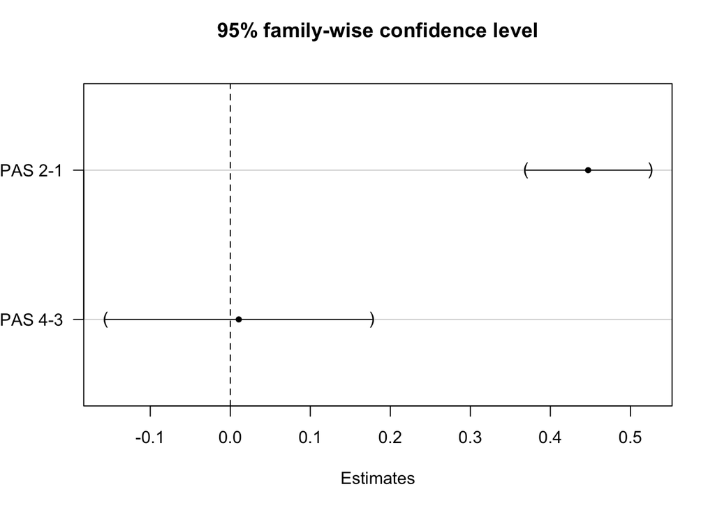

```r
# a vizualization of the difference:
plot(gh, xlab= "Estimates")
```

$~$ *Eyeballing the plot we see no overlap in the two 95% confidence intervals, which indicates a ‘true’ difference between the differences of PAS2-PAS1 (0.44718) and PAS4-PAS3 (0.01060).*